# Analysis and Visualization of Data for Bach Visualization Project

This notebook conducts analysis of the questionnaire presented to the live and livestreaming audiences of MusicLab Copenhagen and a follow-up sample of online participants who responded to continuous rating scales and the same survey that was provided to the concert audience. The survey can be found here: https://oslopsych.az1.qualtrics.com/jfe/form/SV_9n5uwhPGOHJqqHQ

```r
citation()
```

```
##
##   R Core Team (2023). _R: A Language and Environment for Statistical
##   Computing_. R Foundation for Statistical Computing, Vienna, Austria.
##   <https://www.R-project.org/>.
##
## A BibTeX entry for LaTeX users is
##
##   @Manual{,
##     title = {R: A Language and Environment for Statistical Computing},
##     author = {{R Core Team}},
##     organization = {R Foundation for Statistical Computing},
##     address = {Vienna, Austria},
##     year = {2023},
##     url = {https://www.R-project.org/},
##   }
##
## We have invested a lot of time and effort in creating R, please cite it
## when using it for data analysis. See also 'citation("pkgname")' for
## citing R packages.
```

```r
citation("psych")
```

```
##
##   William Revelle (2023). _psych: Procedures for Psychological,
##   Psychometric, and Personality Research_. Northwestern University,
##   Evanston, Illinois. R package version 2.3.3,
##   <https://CRAN.R-project.org/package=psych>.
##
## A BibTeX entry for LaTeX users is
##
##   @Manual{,
##     title = {psych: Procedures for Psychological, Psychometric, and Personality Research},
##     author = {{William Revelle}},
##     organization = {Northwestern University},
##     address = {Evanston, Illinois},
##     year = {2023},
##     note = {R package version 2.3.3},
##     url = {https://CRAN.R-project.org/package=psych},
##   }
```

```r
citation("lme4")
```

```
##
##   Douglas Bates, Martin Maechler, Ben Bolker, Steve Walker (2015).
##   Fitting Linear Mixed-Effects Models Using lme4. Journal of
##   Statistical Software, 67(1), 1-48. doi:10.18637/jss.v067.i01.
##
## A BibTeX entry for LaTeX users is
##
##   @Article{,
##     title = {Fitting Linear Mixed-Effects Models Using {lme4}},
##     author = {Douglas Bates and Martin M{\"a}chler and Ben Bolker and Steve Walker},
##     journal = {Journal of Statistical Software},
##     year = {2015},
##     volume = {67},
##     number = {1},
##     pages = {1--48},
##     doi = {10.18637/jss.v067.i01},
##   }
```

# Import libraries

```r
packages = c("psych", "readxl","readr", "magrittr", "reshape2","ggpubr", "ltm","janitor", "PerformanceAnalytics", "tidyverse", "lme4", "ggforce", "cowplot", "car") # car: companionto applied regression

## Now load or install&load all
package.check <- lapply(
  packages,
  FUN = function(x) {
    if (!require(x, character.only = TRUE)) {
      install.packages(x, dependencies = TRUE)
      library(x, character.only = TRUE)
    }
  }
)
```

```
## ✖ ggplot2::%+%()     masks psych::%+%()
##
##
##
##
##
##
##
##
##
##
##
##
##
##
##
```

```r
source("useful_functions.R")
```

# Load Data

## Live Concert

```r
df.full<-readRDS(file = "../output/Prepared_Data.Rda")

# rename ParticipantCode to Pt_ID because that is the name I began by using here.
names(df.full)[1]<-"Pt_ID"
```

```r
dat<-df.full%>%
  select(Pt_ID, group, age, EC,AIMS,musician_status, fan, perceive_Bach:style_Bach)%>%
  filter(group == "Live")%>%
  select(-group)
```

## Follow up study

```r
# raw
rawurlfile = "https://raw.githubusercontent.com/finn42/Bach_Viz_Responses/main/data_input/raw.csv"
raw<-read_csv(url(rawurlfile))
# edited
editedurlfile="https://raw.githubusercontent.com/finn42/Bach_Viz_Responses/main/data_input/edited.csv"
edited<-read_csv(url(editedurlfile))
```

### Save the edited dataframe for use in an anonymized code example

```r
#save(edited, file = "Online_Study_Data.rda")
```

# Organize data

## Online follow-up

Add ID column

```r
edited<-tibble::rowid_to_column(edited, "Pt_ID")
```

- I will need to also keep track of if they viewed the simple or the complex first

Label as simple or complex first or second.

Note: participants could have seen any combination of complex and simple.(e.g. 1C, 1S or 2C or 2S)

```r
edited<-edited%>%mutate(type1 = case_when(
    !is.na(simple1) ~ "Simple",
    !is.na(complex1) ~ "Complex",
    ))

edited<-edited%>%mutate(type2 = case_when(
    !is.na(simple2) ~ "Simple",
    !is.na(complex2) ~ "Complex",
    ))
```

Drop the unnecessary data of continuous ratings

```r
edited<-edited%>%select(!c(complex1, simple1, complex2, simple2))
```

Desired colnames

```r
col_names<-names(dat)[7:length(dat)]
print(col_names)
```

```
## [1] "perceive_Bach"          "instruments_Bach"       "understanding_Bach"
## [4] "augment_Bach"           "disturb_Bach"           "enhance_Bach"
## [7] "emotionally_moved_Bach" "familiar_Bach"          "style_Bach"
```

Which cols correspond to the first video and which the second?

```r
# questions on the first video
transpose(raw[1, c('Q3', 'Q4', 'Q5', 'Q6', 'Q7', 'Q8', 'Q9','Q11', 'Q12')]) # questions corresponding to column labels
```

```
## [[1]]
## [[1]]$Q3
## [1] "Did you perceive how the visualisation related to the music?"
##
## [[1]]$Q4
## [1] "Did the coloured lines and discs help you follow the different instruments?"
##
## [[1]]$Q5
## [1] "Did the visualization influence your understanding of the structural elements of the music?"
##
## [[1]]$Q6
## [1] "Did the visualization augment your appreciation of the repetition of melodic themes?"
##
## [[1]]$Q7
## [1] "Compared to seeing a performance without a visualization, did this visualization disturb and degrade your appreciation of the piece?"
##
## [[1]]$Q8
## [1] "Did the visualization enhance your experience of the music?"
##
## [[1]]$Q9
## [1] "Did the visualization help you be more emotionally moved by the music?"
##
## [[1]]$Q11
## [1] "Were you familiar with the music that you heard?"
##
## [[1]]$Q12
## [1] "Were you familiar with this style of music (Bach fugues)?"
```

```r
# questions on the second video
transpose(raw[1, c('Q21', 'Q22', 'Q23', 'Q24', 'Q25', 'Q26', 'Q27')]) # questions corresponding to column labels
```

```
## [[1]]
## [[1]]$Q21
## [1] "Did you perceive how the visualisation related to the music?"
##
## [[1]]$Q22
## [1] "Did the coloured lines and discs help you follow the different instruments?"
##
## [[1]]$Q23
## [1] "Did the visualization influence your understanding of the structural elements of the music?"
##
## [[1]]$Q24
## [1] "Did the visualization augment your appreciation of the repetition of melodic themes?"
##
## [[1]]$Q25
## [1] "Compared to seeing a performance without a visualization, did this visualization disturb and degrade your appreciation of the piece?"
##
## [[1]]$Q26
## [1] "Did the visualization enhance your experience of the music?"
##
## [[1]]$Q27
## [1] "Did the visualization help you be more emotionally moved by the music?"
```

```r
# questions on personal chars
transpose(raw[1, c('Q49', 'Q52', 'Q53', 'Q54', 'Q58')]) # questions corresponding to column labels
```

```
## [[1]]
## [[1]]$Q49
## [1] "Please select the statement that is most correct."
##
## [[1]]$Q52
## [1] "What is your age?"
##
## [[1]]$Q53
## [1] "What is your gender?"
##
## [[1]]$Q54
## [1] "Which title best describes you?"
##
## [[1]]$Q58
## [1] "If you have any remarks concerning the experiment, feel free to write them below."
```

Rename personal Characteristic cols

```r
colnames(edited)[which(names(edited) == "Q49")] <- "quiz"
colnames(edited)[which(names(edited) == "Q52")] <- "age"
colnames(edited)[which(names(edited) == "Q53")] <- "gender"
colnames(edited)[which(names(edited) == "Q54")] <- "musician_status"
```

We also had a question that was a quiz question to truly test participants’ Grasping of the visualization:

Please select the statement that is most correct. X The color of the discs corresponded to the emotion in the music. X Each line corresponded to a different string on the violin. –> Each disc corresponded to a different instrument. X The color of the lines corresponded to the harmonic color of the music.

Calculate quiz result

```r
edited$quiz_result<-0
edited$quiz_result[edited$quiz==3]<-1
```

How many participants answered the quiz correctly?

```r
edited%>%group_by(quiz)%>%summarise(n())
```

| quiz | n() |
| --- | --- |
| 2 | 3 |
| 3 | 46 |
| 4 | 2 |
| NaN | 2 |

```r
edited%>%group_by(quiz_result)%>%summarise(n())
```

| quiz_result | n() |
| --- | --- |
| 0 | 7 |
| 1 | 46 |

Rename the columns based on if they viewed the simple or complex first

To do this, I need to create new dataframes.

```r
# first set of Qs
first_video<-edited%>%select(Pt_ID,type1, Q3:Q12)
# second set of Qs
second_video<-edited%>%select(Pt_ID, type2, Q21:Q27)
```

Rename cols

```r
names(first_video)[3:11]<-col_names
names(second_video)[3:9]<-col_names[1:(length(col_names)-2)]
```

Pivot longer

```r
first_long<-first_video%>%
  pivot_longer(!c(Pt_ID,type1), names_to = "question", values_to = "response")

second_long<-second_video%>%
  pivot_longer(!c(Pt_ID,type2), names_to = "question", values_to = "response")
```

Rename type

```r
colnames(first_long)[2]<-"type"
colnames(second_long)[2]<-"type"

first_long$order<-"first"
second_long$order<-"second"

long<-rbind(first_long, second_long)
long$group<-"Online"
```

Pivot wider

```r
pc<-edited%>%select(Pt_ID, age, musician_status)
online_df<-full_join(long, pc, by = "Pt_ID")
online_df.wide<-online_df%>%pivot_wider(names_from = question, values_from= response)
```

Factor musician status

```r
online_df.wide$musician_status<-factor(online_df.wide$musician_status)
online_df.wide$musician_status<-fct_collapse(online_df.wide$musician_status,"Tone-deaf" = "1", "Nonmusician" = "2", "Music-loving nonmusician" ="3", "Amateur musician" = "4", "Serious amateur musician" = "5", "Semiprofessional musician"= "6", "Professional musician" = "7")
online_df.wide$Pt_ID<-factor(online_df.wide$Pt_ID)
```

The scale was 1-7 for the familiar and style items therefore subtract 1 to be on the same 0-6 scale as in the live data

```r
# if statement to make sure this does not happen twice.
if(max(online_df.wide$familiar_Bach, na.rm = TRUE) == 7){
  online_df.wide$familiar_Bach<-online_df.wide$familiar_Bach-1
}
if(max(online_df.wide$style_Bach, na.rm = TRUE) == 7){
  online_df.wide$style_Bach<-online_df.wide$style_Bach-1
}
```

## Live

Remove the cols that are not in the online data

```r
names(dat)
```

```
##  [1] "Pt_ID"                  "age"                    "EC"
##  [4] "AIMS"                   "musician_status"        "fan"
##  [7] "perceive_Bach"          "instruments_Bach"       "understanding_Bach"
## [10] "augment_Bach"           "disturb_Bach"           "enhance_Bach"
## [13] "emotionally_moved_Bach" "familiar_Bach"          "style_Bach"
```

```r
live_dat<-dat%>%select(-EC, -AIMS, -fan)

live_dat$group<-"Live"
live_dat$type<-"Complex"
live_dat$order<-"live"
```

## Join together

Join the online and the concert results.

```r
full_data<-full_join(live_dat, online_df.wide)
```

[output not shown]

Convert to long again

```r
other_vars<-c("Pt_ID", "age", "musician_status", "group", "type","order")

full_data.long<-full_data%>%
  pivot_longer(!other_vars, names_to = "question", values_to = "response")
full_data.long$question<-factor(full_data.long$question, levels = c("perceive_Bach", "instruments_Bach","understanding_Bach", "augment_Bach", "disturb_Bach", "enhance_Bach", "emotionally_moved_Bach", "familiar_Bach","style_Bach"), labels = c("Perceive", "Instruments","Understanding", "Augment", "Disturb", "Enhance", "Moved", "Familiar","Style"))

scale_five<-c("Perceive", "Instruments","Understanding", "Augment", "Disturb", "Enhance", "Moved")
full_data.long$facet<-"7-item scale"
full_data.long$facet[full_data.long$question %in% scale_five]<-"5-item scale"

full_data.long$facet_group[full_data.long$type == "Simple"]<-"Online - Simple"
full_data.long$facet_group[full_data.long$type == "Complex"]<-"Online - Complex"
full_data.long$facet_group[full_data.long$group == "Live"]<-"Live"

full_data.long$facet_group<-factor(full_data.long$facet_group, levels = c("Live", "Online - Simple", "Online - Complex"))

# Why are there NA in facet_group?
## Because Participant 32 in the online experiment did not respond in the live rating of the second piece at all therefore we can remove the NAs that exist for this participant
full_data.long<-full_data.long%>%filter(!(Pt_ID == "32" & is.na(type)))
```

# Visualize

### Complex: Live versus Online - Stacked bar chart

[figure not shown]

```r
Title = "Simple Bach Visualization"

plot_data<-full_data.long%>%filter(question %in% scale_five)%>%filter(type == "Complex")%>%filter(!is.na(response))

plot_data$Response<-factor(plot_data$response, levels = c("5", "4", "3", "2", "1"), labels = c("5 Totally", "4", "3", "2", "1 Not at all"))

# Put the sample size in the subtitle
n = plot_data%>%group_by(group)%>%summarise(n = n_distinct(Pt_ID))

Subtitle = paste0("Live (n = ", n$n[n$group == "Live"], ") and Online (n = ", n$n[n$group == "Online"],")")

plot_data%>%ggplot(aes(x = question, fill = Response))+
  geom_bar(position = "fill")+
  labs(title=Title, subtitle = Subtitle)+
  scale_fill_brewer(palette = "Reds", direction = -1) +
  theme_minimal()+
  xlab("Question")+
  ylab("Proportion")+
  facet_grid(rows = vars(group)) +
  theme(axis.text.x = element_text(angle = 30)) #, vjust = 0.5, hjust=1))
```

```r
graphname<-paste0("../plots/Bar_",Title,"subtitle.png")

ggsave(graphname,
       width = 15,
       height = 10,
       units = 'cm',
       dpi = 500)
```

## Online: Complex versus simple

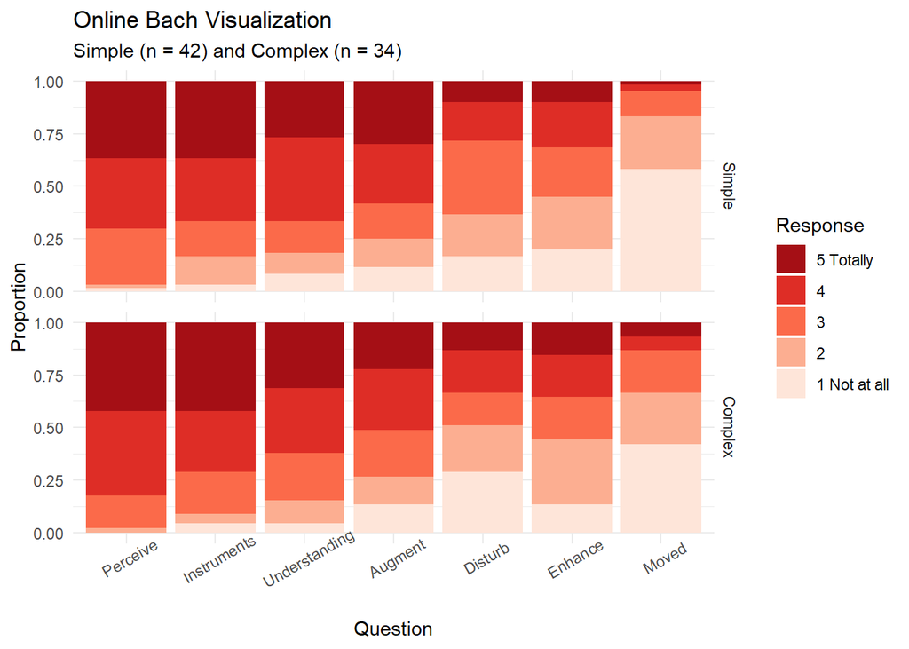

```r
Title = "Online Bach Visualization"

plot_data<-full_data.long%>%filter(question %in% scale_five)%>%filter(group == "Online")

plot_data$Response<-factor(plot_data$response, levels = c("5", "4", "3", "2", "1"), labels = c("5 Totally", "4", "3", "2", "1 Not at all"))

plot_data$type<-factor(plot_data$type, levels = c("Simple", "Complex"))

# Put the sample size in the subtitle
n = plot_data%>%group_by(type)%>%summarise(n = n_distinct(Pt_ID))

Subtitle = paste0("Simple (n = ", n$n[n$type == "Simple"], ") and Complex (n = ", n$n[n$type == "Complex"],")")

plot_data%>%ggplot(aes(x = question, fill = Response))+
  geom_bar(position = "fill")+
  labs(title=Title, subtitle = Subtitle)+
  scale_fill_brewer(palette = "Reds", direction = -1) +
  theme_minimal()+
  xlab("Question")+
  ylab("Proportion")+
  facet_grid(rows = vars(type)) +
  theme(axis.text.x = element_text(angle = 30)) #, vjust = 0.5, hjust=1))
```

```r
graphname<-paste0("../plots/Bar_Complex_Simple",Title,".png")

ggsave(graphname,
       width = 15,
       height = 10,
       units = 'cm',
       dpi = 500)
```

## Single chart: Live, Simple, Complex

When comparing live to simple and simple to complex, we are having a repetition of information. Additionally, we could make separate plots to give them separate colors and then combine the plots with cowplot for example.

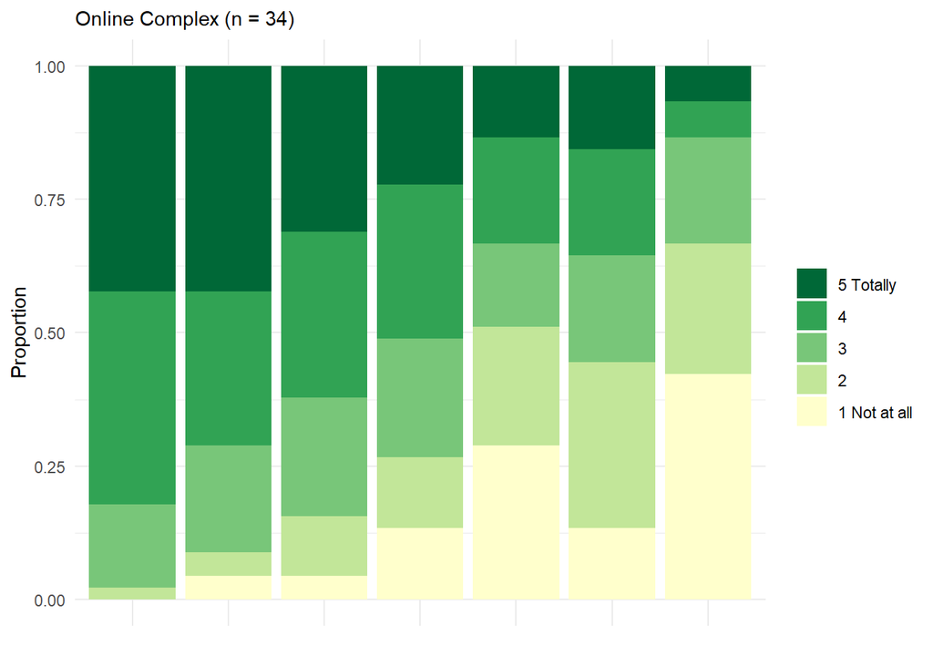

```r
Title = "Bach Visualization"

# Live
plot_data<-full_data.long%>%filter(question %in% scale_five)%>%filter(group == "Live")%>%filter(!is.na(response))

n_Live = plot_data%>%summarise(n = n_distinct(Pt_ID))

Subtitle = paste0("Live Complex (n = ", n_Live$n, ")")

plot_data$Response<-factor(plot_data$response, levels = c("5", "4", "3", "2", "1"), labels = c("5 Totally", "4", "3", "2", "1 Not at all"))

p_live<-plot_data%>%ggplot(aes(x = question, fill = Response))+
  geom_bar(position = "fill")+
  labs(title=Title, subtitle = Subtitle)+
  scale_fill_brewer(palette = "Reds", direction = -1, name = "") +
  theme_minimal()+
  xlab("")+
  ylab("Proportion")+
  theme(axis.text.x = element_blank())
  #theme(axis.text.x = element_text(angle = 30)) #, vjust = 0.5, hjust=1))

# Complex
plot_data<-full_data.long%>%filter(question %in% scale_five)%>%filter(group == "Online" & type == "Complex")%>%filter(!is.na(response))

n_Complex = plot_data%>%summarise(n = n_distinct(Pt_ID))

Subtitle = paste0("Online Complex (n = ", n_Complex$n, ")")

plot_data$Response<-factor(plot_data$response, levels = c("5", "4", "3", "2", "1"), labels = c("5 Totally", "4", "3", "2", "1 Not at all"))

p_complex<-plot_data%>%ggplot(aes(x = question, fill = Response))+
  geom_bar(position = "fill")+
  labs(subtitle = Subtitle)+
  scale_fill_brewer(palette = "YlGn", direction = -1, name = "") + # same palette to reflect that they are the same group!@
  theme_minimal()+
  xlab("")+
  ylab("Proportion")+
  theme(axis.text.x = element_blank())
  #theme(axis.text.x = element_text(angle = 30, vjust = 1, hjust=1))

p_complex
```

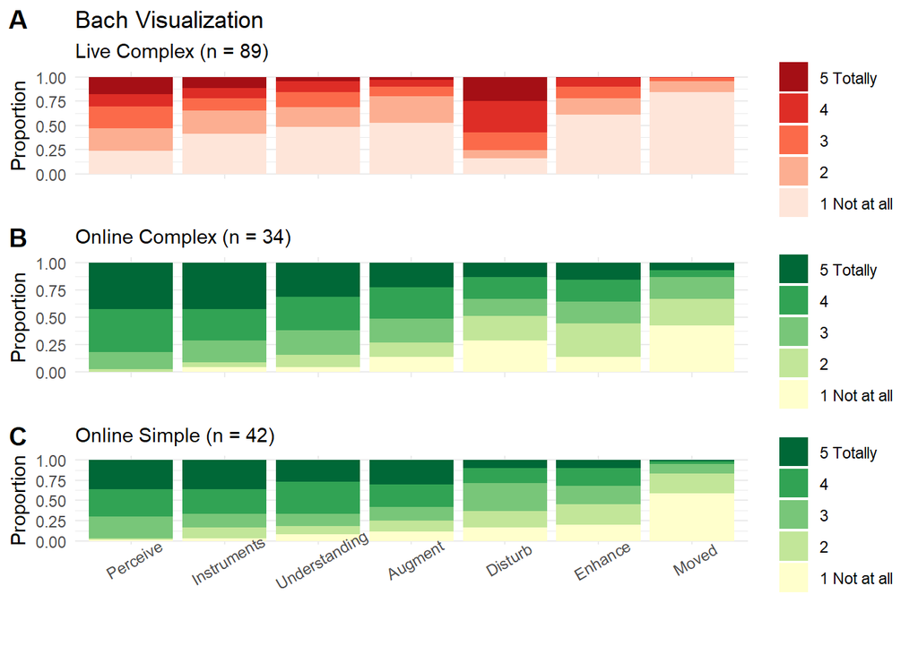

```r
# Simple
plot_data<-full_data.long%>%filter(question %in% scale_five)%>%filter(group == "Online" & type == "Simple")%>%filter(!is.na(response))

n_Simple = plot_data%>%summarise(n = n_distinct(Pt_ID))

Subtitle = paste0("Online Simple (n = ", n_Simple$n,")")

plot_data$Response<-factor(plot_data$response, levels = c("5", "4", "3", "2", "1"), labels = c("5 Totally", "4", "3", "2", "1 Not at all"))

p_simple<-plot_data%>%ggplot(aes(x = question, fill = Response))+
  geom_bar(position = "fill")+
  labs(subtitle = Subtitle)+
  scale_fill_brewer(palette = "YlGn", direction = -1, name = "") +
  theme_minimal()+
  xlab("")+
  ylab("Proportion")+
  #theme(axis.text.x = element_blank())
  theme(axis.text.x = element_text(angle = 30)) #, vjust = 0.5, hjust=1))

plot_grid(
  p_live, p_complex, p_simple,
  labels = "AUTO", ncol = 1,
  rel_heights = c(1.1,1,1.2)
)
```

```r
graphname<-paste0("../plots/Bar_3_",Title,".png")

ggsave(graphname,
       width = 15,
       height = 20,
       units = 'cm',
       dpi = 500)
```

## Single chart: Live, First: Simple, Complex; Second: Simple, Complex

The order of presentation may be important therefore make a plot that splits information into simple first, simple second, complex first, complex second

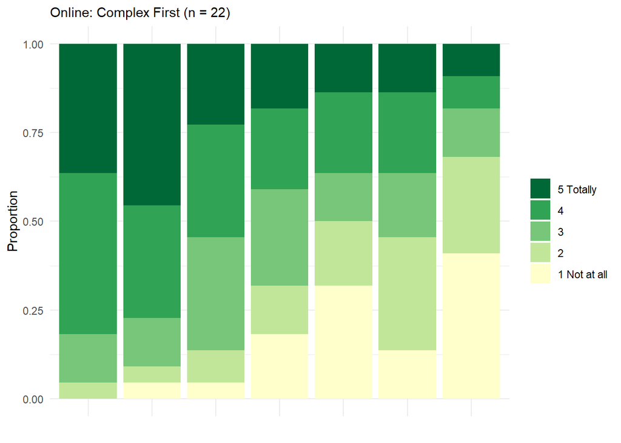

```r
Title = "Bach Visualization"

# Live
plot_data<-full_data.long%>%filter(question %in% scale_five)%>%filter(group == "Live")%>%filter(!is.na(response))

n_Live = plot_data%>%summarise(n = n_distinct(Pt_ID))

Subtitle = paste0("Live: Complex (n = ", n_Live$n, ")")

plot_data$Response<-factor(plot_data$response, levels = c("5", "4", "3", "2", "1"), labels = c("5 Totally", "4", "3", "2", "1 Not at all"))

p_live<-plot_data%>%ggplot(aes(x = question, fill = Response))+
  geom_bar(position = "fill")+
  labs(title=Title, subtitle = Subtitle)+
  scale_fill_brewer(palette = "Reds", direction = -1, name = "") +
  theme_minimal()+
  xlab("")+
  ylab("Proportion")+
  theme(axis.text.x = element_blank())
  #theme(axis.text.x = element_text(angle = 30)) #, vjust = 0.5, hjust=1))

# Complex First
plot_data<-full_data.long%>%filter(question %in% scale_five)%>%filter(group == "Online" & type == "Complex" & order == "first")%>%filter(!is.na(response))

n_Complex_First = plot_data%>%summarise(n = n_distinct(Pt_ID))

Subtitle = paste0("Online: Complex First (n = ", n_Complex_First$n, ")")

plot_data$Response<-factor(plot_data$response, levels = c("5", "4", "3", "2", "1"), labels = c("5 Totally", "4", "3", "2", "1 Not at all"))

p_complex_first<-plot_data%>%ggplot(aes(x = question, fill = Response))+
  geom_bar(position = "fill")+
  labs(subtitle = Subtitle)+
  scale_fill_brewer(palette = "YlGn", direction = -1, name = "") + # same palette to reflect that they are the same group!@
  theme_minimal()+
  xlab("")+
  ylab("Proportion")+
  theme(axis.text.x = element_blank())
  #theme(axis.text.x = element_text(angle = 30, vjust = 1, hjust=1))

p_complex_first
```

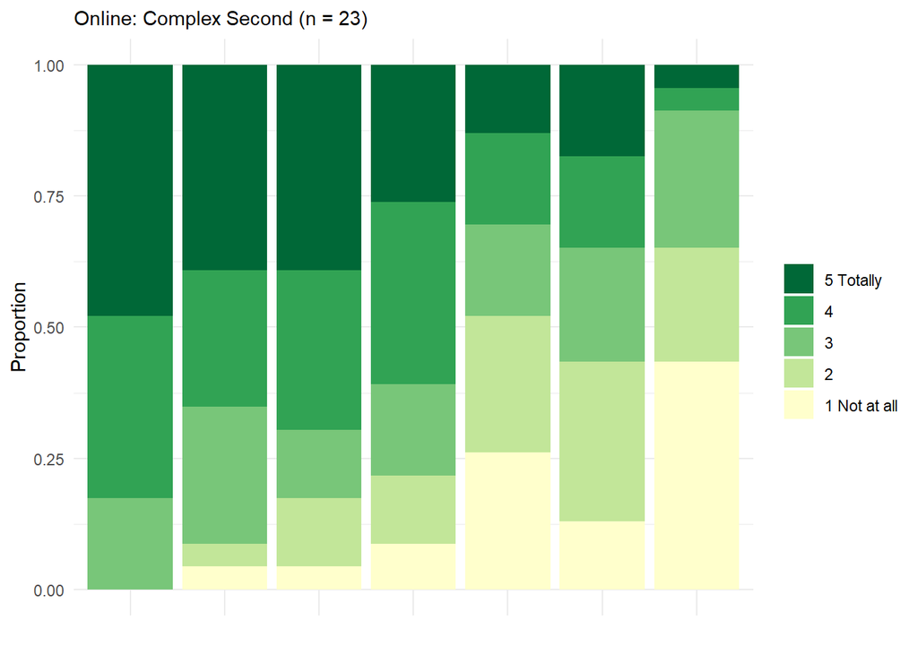

```r
# Simple First
plot_data<-full_data.long%>%filter(question %in% scale_five)%>%filter(group == "Online" & type == "Simple" & order == "first")%>%filter(!is.na(response))

n_Simple_first = plot_data%>%summarise(n = n_distinct(Pt_ID))

Subtitle = paste0("Online: Simple First (n = ", n_Simple_first$n,")")

plot_data$Response<-factor(plot_data$response, levels = c("5", "4", "3", "2", "1"), labels = c("5 Totally", "4", "3", "2", "1 Not at all"))

p_simple_first<-plot_data%>%ggplot(aes(x = question, fill = Response))+
  geom_bar(position = "fill")+
  labs(subtitle = Subtitle)+
  scale_fill_brewer(palette = "YlGn", direction = -1, name = "") +
  theme_minimal()+
  xlab("")+
  ylab("Proportion")+
  theme(axis.text.x = element_blank())
  #theme(axis.text.x = element_text(angle = 30)) #, vjust = 0.5, hjust=1))

# Complex Second
plot_data<-full_data.long%>%filter(question %in% scale_five)%>%filter(group == "Online" & type == "Complex" & order == "second")%>%filter(!is.na(response))

n_Complex_Second = plot_data%>%summarise(n = n_distinct(Pt_ID))

Subtitle = paste0("Online: Complex Second (n = ", n_Complex_Second$n, ")")

plot_data$Response<-factor(plot_data$response, levels = c("5", "4", "3", "2", "1"), labels = c("5 Totally", "4", "3", "2", "1 Not at all"))

p_complex_second<-plot_data%>%ggplot(aes(x = question, fill = Response))+
  geom_bar(position = "fill")+
  labs(subtitle = Subtitle)+
  scale_fill_brewer(palette = "YlGn", direction = -1, name = "") + # same palette to reflect that they are the same group!@
  theme_minimal()+
  xlab("")+
  ylab("Proportion")+
  theme(axis.text.x = element_blank())
  #theme(axis.text.x = element_text(angle = 30, vjust = 1, hjust=1))

p_complex_second
```

[figure not shown]

```r
# Simple First
plot_data<-full_data.long%>%filter(question %in% scale_five)%>%filter(group == "Online" & type == "Simple" & order == "second")%>%filter(!is.na(response))

n_Simple_second = plot_data%>%summarise(n = n_distinct(Pt_ID))

Subtitle = paste0("Online: Simple Second (n = ", n_Simple_second$n,")")

plot_data$Response<-factor(plot_data$response, levels = c("5", "4", "3", "2", "1"), labels = c("5 Totally", "4", "3", "2", "1 Not at all"))

p_simple_second<-plot_data%>%ggplot(aes(x = question, fill = Response))+
  geom_bar(position = "fill")+
  labs(subtitle = Subtitle)+
  scale_fill_brewer(palette = "YlGn", direction = -1, name = "") +
  theme_minimal()+
  xlab("")+
  ylab("Proportion")+
  #theme(axis.text.x = element_blank())
  theme(axis.text.x = element_text(angle = 30)) #, vjust = 0.5, hjust=1))

plot_grid(
  p_live, p_complex_first, p_simple_first, p_complex_second, p_simple_second,
  labels = "AUTO", ncol = 1,
  rel_heights = c(1.15,1,1,1,1.3)
)
```

```r
graphname<-paste0("../plots/Bar_5_",Title,".png")

ggsave(graphname,
       width = 15,
       height = 25,
       units = 'cm',
       dpi = 500)
```

## Online: SS, SC, CS, CC

Add subgroup class: SS, SC, CS, CC

```r
necessary_info<-online_df.wide%>%select(Pt_ID, order, type)
necessary_info.wide<-necessary_info%>%pivot_wider(names_from = order, values_from = type)
necessary_info.wide$Subgroup[necessary_info.wide$first == "Simple"&necessary_info.wide$second == "Simple"]<-"SS"
necessary_info.wide$Subgroup[necessary_info.wide$first == "Simple"&necessary_info.wide$second == "Complex"]<-"SC"
necessary_info.wide$Subgroup[necessary_info.wide$first == "Complex"&necessary_info.wide$second == "Simple"]<-"CS"
necessary_info.wide$Subgroup[necessary_info.wide$first == "Complex"&necessary_info.wide$second == "Complex"]<-"CC"

subgroups<-necessary_info.wide%>%select(Pt_ID, Subgroup)

#join with full_data.long
full_data.long<-full_data.long%>%full_join(subgroups, by = "Pt_ID")
```

[output not shown]

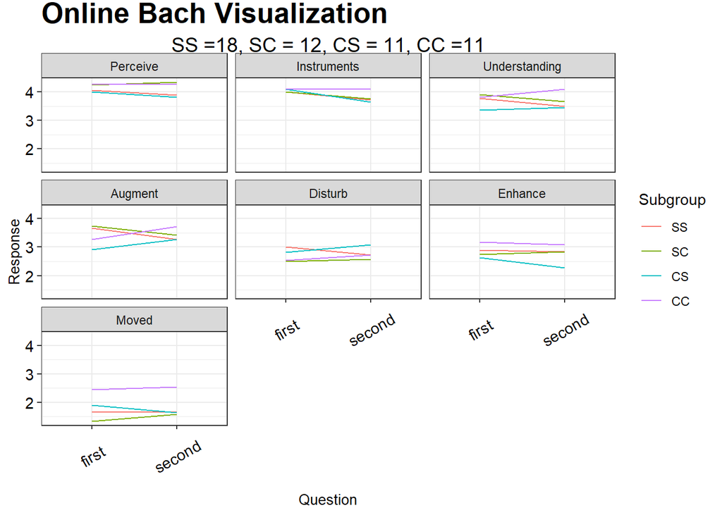

```r
Title = "Online Bach Visualization"

plot_data<-full_data.long%>%filter(question %in% scale_five)%>%filter(group == "Online")
plot_data$Subgroup<-factor(plot_data$Subgroup, levels = c("SS", "SC", "CS", "CC"))

# Put the sample size in the subtitle

n = plot_data%>%group_by(Subgroup)%>%summarise(n = n_distinct(Pt_ID))

Subtitle = paste0("SS =", n$n[n$Subgroup == "SS"], ", SC = ", n$n[n$Subgroup == "SC"],", CS = ", n$n[n$Subgroup == "CS"],", CC =", n$n[n$Subgroup =="CC"])

summary_data<-plot_data%>%group_by(Subgroup, order, question)%>%summarise(Response = mean(response))%>%filter(!is.na(Subgroup))
summary_data%>%ggplot(aes(x = order, y = Response, color = Subgroup, group = Subgroup))+
  geom_line()+
  #geom_point()+
  labs(title=Title, subtitle = Subtitle)+
  theme_DSQ()+
  xlab("Question")+
  ylab("Response")+
  facet_wrap(. ~ question) +
  theme(axis.text.x = element_text(angle = 30)) #, vjust = 0.5, hjust=1))
```

```r
graphname<-paste0("../plots/Line_",Title,".png")

ggsave(graphname,
       width = 15,
       height = 15,
       units = 'cm',
       dpi = 500)
```

## Familiar with Piece and Style

Visualize differences between the audiences on their familiarity Were you familiar with the music that you heard? 0 = I have never heard it before - 6 - I am very familiar with the music Were you familiar with this style of music (Bach fugues)? 0 = I have never heard it before - 6 = I am very familiar with this type of music

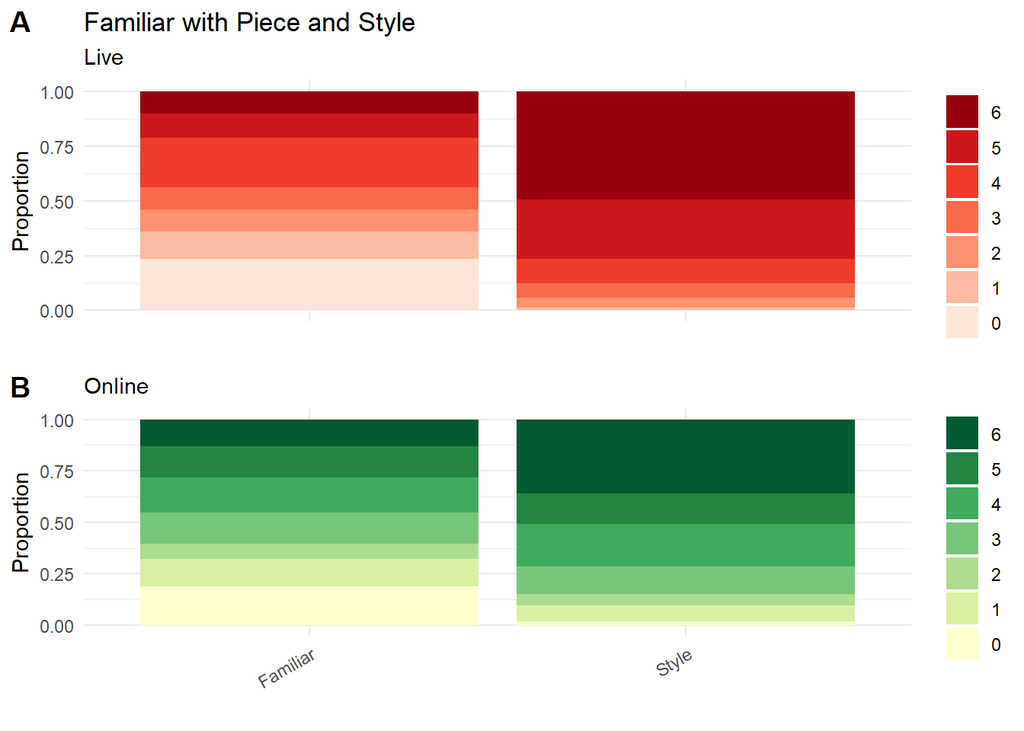

```r
plot_data<-full_data.long%>%filter(!question %in% scale_five)%>%filter(! is.na(response))

plot_data$Response<-factor(plot_data$response, levels = c("6", "5", "4", "3", "2", "1", "0"), labels = c("6","5", "4", "3", "2", "1", "0"))

Title= "Familiar with Piece and Style"
Subtitle = "Live"

fam_live<-plot_data%>%filter(group == "Live")%>%ggplot(aes(x = question, fill = Response))+
  geom_bar(position = "fill")+
  labs(title = Title, subtitle = Subtitle)+
  scale_fill_brewer(palette = "Reds", direction = -1, name = "") + # same palette to reflect that they are the same group!@
  theme_minimal()+
  #facet_grid(rows = vars(group)) +
  xlab("")+
  ylab("Proportion")+
  theme(axis.text.x = element_blank())
  #theme(axis.text.x = element_text(angle = 30, vjust = 1, hjust=1))

Subtitle = "Online"
fam_online<-plot_data%>%filter(group == "Online")%>%ggplot(aes(x = question, fill = Response))+
  geom_bar(position = "fill")+
  labs(subtitle = Subtitle)+
  scale_fill_brewer(palette = "YlGn", direction = -1, name = "") + # same palette to reflect that they are the same group!@
  theme_minimal()+
  #facet_grid(rows = vars(group)) +
  xlab("")+
  ylab("Proportion")+
  #theme(axis.text.x = element_blank())
  theme(axis.text.x = element_text(angle = 30, vjust = 1, hjust=1))

plot_grid(
  fam_live, fam_online,
  labels = "AUTO", ncol = 1
  #rel_heights = c(1.1,1,1.2)
)
```

```r
graphname<-paste0("../plots/Bar_",Title,".png")

ggsave(graphname,
       width = 10,
       height = 15,
       units = 'cm',
       dpi = 500)
```

## Violin Plot: Live only

```r
# transform the response scale of the familiarity questions to 1-5
## 0-->1(*5/7 + 1)
#dat<-dat%>%mutate(style_Bach_t = (style_Bach+1)*5/7,familiar_Bach_t = (familiar_Bach+1)*5/7)

# Or just make a facet grid so that you can have different y scales? See below
#facet<-c(1,1,1,1,1,1,1,2,2)

personal_chars<-c("Pt_ID", "age", "EC", "AIMS","musician_status", "fan")

dat_long<-dat%>%
  pivot_longer(!all_of(personal_chars), names_to = "question", values_to = "response")

dat_long$question<-factor(dat_long$question, levels = c("perceive_Bach", "instruments_Bach","understanding_Bach", "augment_Bach", "disturb_Bach", "enhance_Bach", "emotionally_moved_Bach", "familiar_Bach","style_Bach"), labels = c("Perceive", "Instruments","Understanding", "Augment", "Disturb", "Enhance", "Moved", "Familiar","Style"))

scale_five<-c("Perceive", "Instruments","Understanding", "Augment", "Disturb", "Enhance", "Moved")
dat_long$facet<-"7-item scale"
dat_long$facet[dat_long$question %in% scale_five]<-"5-item scale"
```

### Facet: 5 and 7-item scale

[output not shown]

[output cut: 10 more lines]

[output not shown]

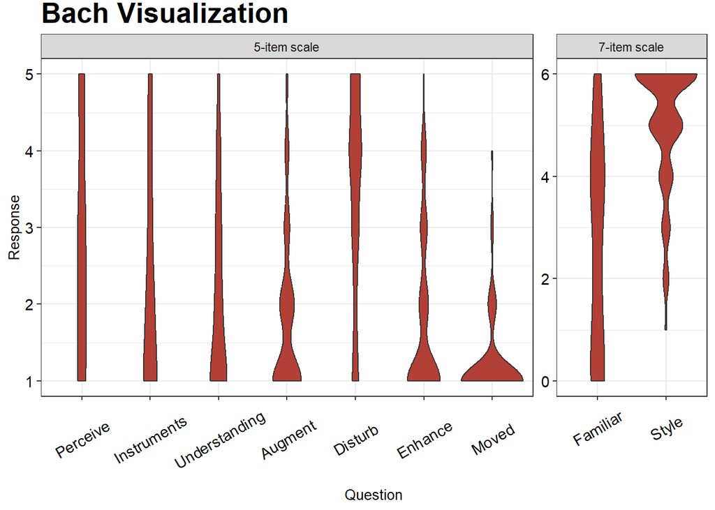

```r
Title = "Bach Visualization"

dat_long%>%ggplot(aes(x = question, y = response))+
  geom_violin(show.legend= FALSE, fill = "#b34036")+
  labs(title=Title)+
  theme_DSQ()+
  xlab("Question")+
  ylab("Response")+
  #facet_wrap(~facet, scales = "free")+
  #facet_grid(. ~ facet, scales = "free", space='free') +
  ggforce::facet_row(vars(facet), scales = 'free', space = 'free')+
  theme(axis.text.x = element_text(angle = 30)) #, vjust = 0.5, hjust=1))
```

```r
graphname<-paste0("../plots/Violin_",Title, ".png")
ggsave(graphname,
       width = 15,
       height = 9,
       units = 'cm',
       dpi = 500)
```

# Statistical Analysis

## Participants

How many participants participated?

```r
# ID pts who did not answer any Bach survey questions

# This line of code drops any participant with even 1 NA in the Bach questionnaire. This indicates that 86 participants answered the Bach questionnaire completely.
#demo_dat<-full_data%>%drop_na(contains("Bach"))%>%select(Pt_ID, group, age, musician_status)%>%distinct()

# Instead we need to drop rows with all NA in the cols
count_dat<-full_data%>%select(Pt_ID, group, contains("Bach"))
count_dat<-count_dat[rowSums(is.na(count_dat)) != ncol(count_dat)-2,] # -2 because need to retain Pt_ID and group in the df

count_dat%>%group_by(group)%>%summarise(count = n())
```

| group | count |
| --- | --- |
| Live | 89 |
| Online | 106 |

```r
# check which vars the 3 participants missed.
live_count_dat<-count_dat%>%filter(group == "Live")
## 1 missed filling "perceive", 2 missed filling "disturb". These participants had no other NAs.
```

Compare demographics between audiences. Compare age and musician status between live and online groups.

```r
demo_dat<-full_data%>%drop_na(contains("Bach"))%>%select(Pt_ID, group, age, musician_status)%>%distinct()

#age
demo_dat%>%group_by(group)%>%summarise(mean = mean(age, na.rm = TRUE), sd = sd(age, na.rm = TRUE))
```

| group | mean | sd |
| --- | --- | --- |
| Live | 55.66667 | 17.64551 |
| Online | 42.22449 | 15.00592 |

```r
#musician status
test<-demo_dat%>%group_by(group,musician_status)%>%summarise(count = n())
test2<-pivot_wider(test, names_from = group, values_from = count )
write.table(test2, file = "musician_status_Bach_live_v_online.txt", sep = ",", quote = FALSE, row.names = F)

library(xtable)
print(xtable(test2, type = "latex"), file = "musician_status_Bach_live_v_online.tex")
```

### Age: Two-sample t-test

The live audience was significantly older than the online audience.

```r
t.test(demo_dat$age~demo_dat$group)
```

```
##
##  Welch Two Sample t-test
##
## data:  demo_dat$age by demo_dat$group
## t = 4.4048, df = 110.86, p-value = 2.454e-05
## alternative hypothesis: true difference in means between group Live and group Online is not equal to 0
## 95 percent confidence interval:
##   7.394872 19.489482
## sample estimates:
##   mean in group Live mean in group Online
##             55.66667             42.22449
```

### Musician status (ordinal) Kruskal Wallis test

The Kruskal Wallis test is used when you have one independent variable with two or more levels and an ordinal dependent variable.

The live audience was less musically sophisticated than the online participants

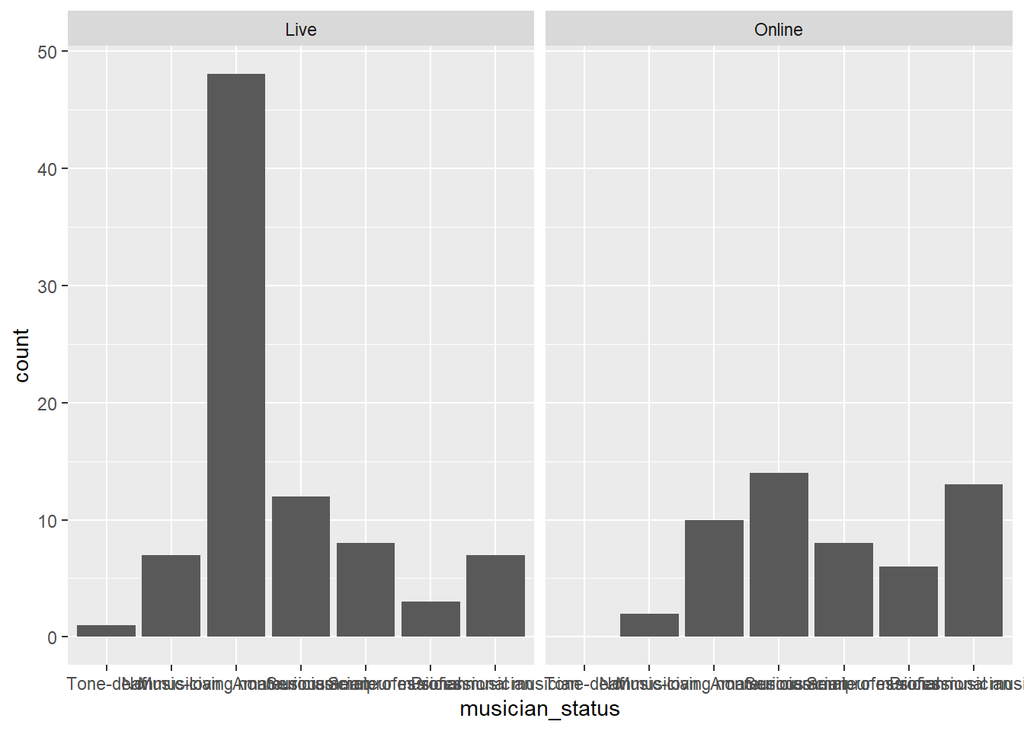

```r
ggplot(demo_dat, aes(x = musician_status))+geom_bar()+facet_grid(cols = vars(group)) # these distributions don't really look the same
```

```r
kruskal.test(musician_status~group, data = demo_dat)
```

```
##
##  Kruskal-Wallis rank sum test
##
## data:  musician_status by group
## Kruskal-Wallis chi-squared = 21.848, df = 1, p-value = 2.951e-06
```

## Correlations

### Live

take a glance with the performance analytics correlation chart

Reload data

```r
personal_chars<-c("Pt_ID", "age", "EC", "AIMS","musician_status", "fan")

dat<-df.full%>%
  select(Pt_ID, group, age, EC,AIMS,musician_status, fan, perceive_Bach:style_Bach)%>%
  filter(group == "Live")%>%
  select(-group)
```

```r
cor_data_Bach<-dat%>%select(!Pt_ID)
```

[output not shown]

[output cut: 126 more lines]

[output not shown]

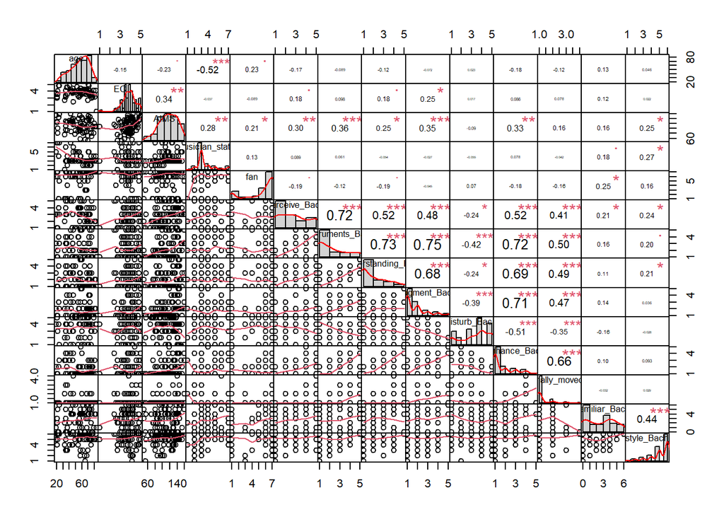

```r
#change musician_status to ranking
cor_data_Bach$musician_status<-as.numeric(cor_data_Bach$musician_status)

#Cross correlation
chart.Correlation(cor_data_Bach, method = "pearson")
```

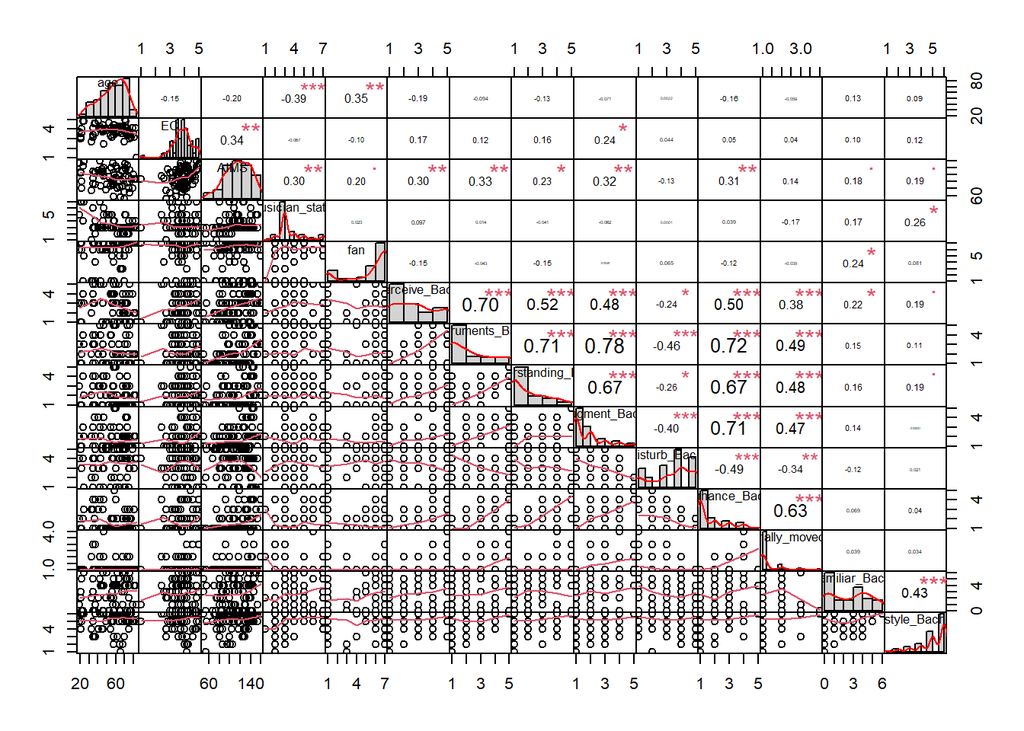

```r
chart.Correlation(cor_data_Bach, method = "spearman")
```

[output not shown]

[output cut: 126 more lines]

[output not shown]

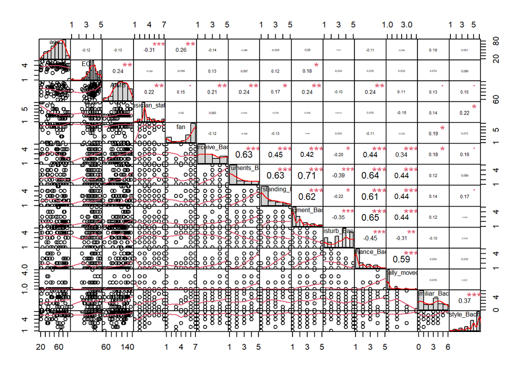

```r
chart.Correlation(cor_data_Bach, method = "kendall")
```

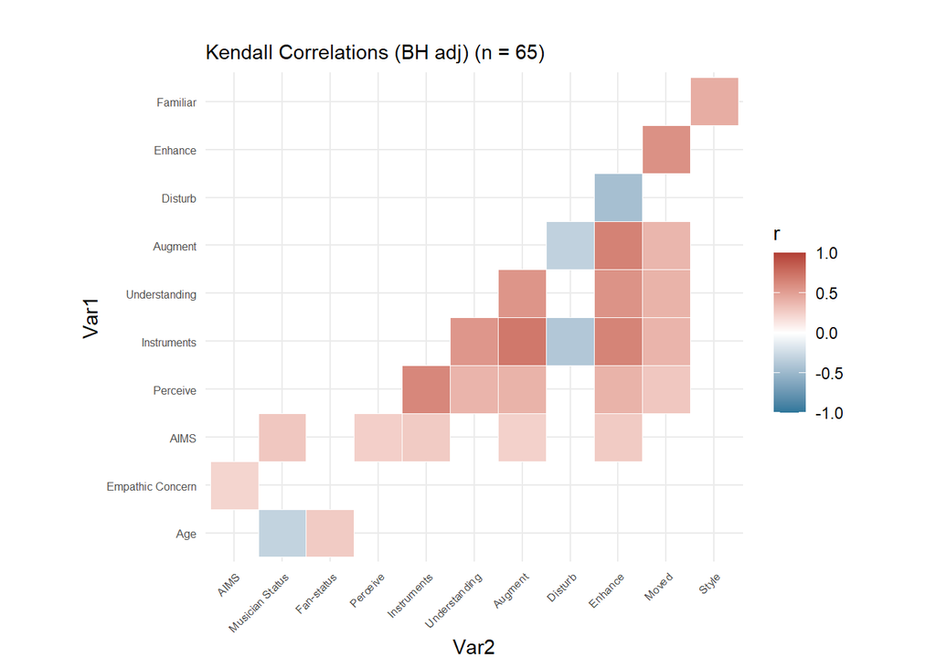

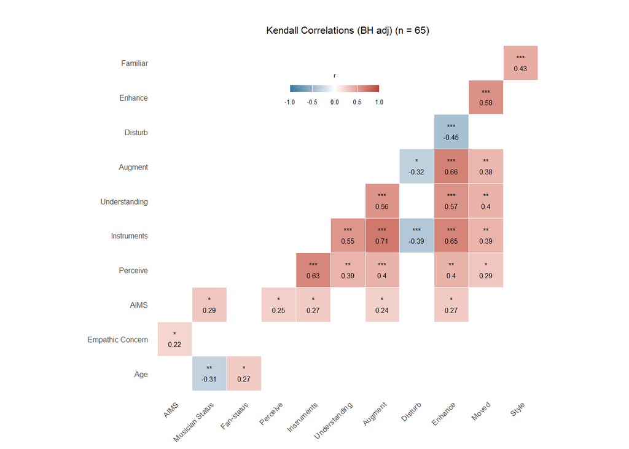

```r
#select only complete
cor_data_Bach_nona<-na.omit(cor_data_Bach) # however maybe you could retain more data if you simply got rid of the age col since this seems to be what is missing most often.
names(cor_data_Bach_nona)<-c("Age", "Empathic Concern","AIMS", "Musician Status", "Fan-status", "Perceive", "Instruments","Understanding", "Augment", "Disturb", "Enhance", "Moved", "Familiar","Style")

# check number of samples
samples<-nrow(cor_data_Bach_nona)
colours_DSQ<-c("#2d769a", "white","#b34036")
title = ""
#title = "Bach Visualization"
subtitle = paste0("Kendall Correlations (BH adj) (n = ", samples, ")")
chart.correlation(cor_data_Bach_nona, colours_DSQ, title, subtitle) #moved the cross-correlation code to the useful_functions script to make this more tidy.
```

```r
graphname<-paste0("../plots/Kendall-Correlations_BachVis.png")
ggsave(graphname,
       width = 10,
       height = 9,
       units = 'cm',
       dpi = 500)
```